[video not shown]

## Multispectral And Hyperspectral Multispectral imaging is a remote sensing technique that involves capturing and analyzing electromagnetic radiation from multiple discrete bands or spectral regions of the electromagnetic spectrum [23]. Unlike true-color images that are composed of red, green, and blue bands, multispectral images consist of data captured in several additional bands beyond the visible range, such as near-infrared (NIR) and shortwave infrared (SWIR) regions while **Hyper spectral imaging** is an advanced remote sensing technique that involves capturing and processing data in hundreds or even thousands of narrow and contiguous spectral bands across the electromagnetic spectrum.

## Electromagnetic Spectrum The electromagnetic (EM) spectrum is the range of all types of EM radiation. Radiation is energy that travels and spreads out as it goes – the visible light that comes from a lamp in your house and the radio waves that come from a radio station are two types of electromagnetic radiation. The other types of EM radiation that make up the electromagnetic spectrum are microwaves, infrared light, ultraviolet light, X-rays and gamma-rays…

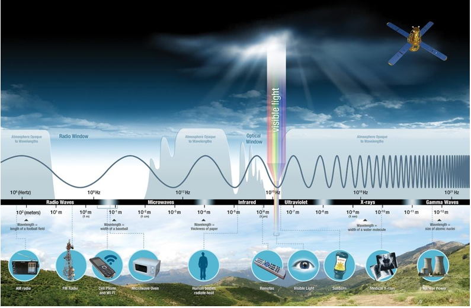

## What is Active and Passive Remote Sensing?

[video not shown]

| **Sensor Type** | **Definition** | **Operation** |
| --- | --- | --- |
| **Active Sensor** | Emits energy or signals into the environment and measures the response or reflection of that energy. | Generates and emits signals (e.g., radio waves, sound waves, lasers) and analyzes responses from the target object. |
| **Passive Sensor** | Relies on naturally available energy, such as sunlight, to measure reflected or emitted signals from objects. | Detects and measures energy naturally emitted or reflected without actively generating signals. |

## Applications of Remote Sensing

### Environmental Monitoring

- Tracking deforestation, desertification, and land degradation.
- Assessing water quality, wetlands, and biodiversity conservation efforts.

### Agriculture

- Monitoring crop health, soil moisture levels, and irrigation planning.
- Identifying pest infestations or nutrient deficiencies through vegetation indices.

### Disaster Management

- Assessing damage caused by natural disasters like hurricanes, earthquakes, floods, and wildfires.
- Mapping areas for emergency response and recovery operations.

### Urban Planning and Development

- Monitoring urban sprawl, land-use change, and infrastructure growth.
- Planning transportation networks and zoning regulations.

### Climate Change Studies

- Tracking changes in glaciers, polar ice caps, and sea-level rise.
- Monitoring greenhouse gas emissions and assessing carbon sinks like forests.

### Water Resource Management

- Mapping river basins, monitoring reservoir levels, and predicting droughts.
- Studying surface and groundwater distribution.

[output not shown]

## Spectral Bands - Landsat 8 OLI

| **Band** | **Description** | **Wavelengths (nm)** | **Resolution (m)** | **Feature Set** |
| --- | --- | --- | --- | --- |
| 1 | Violet-deep Blue (V-D Blue) | 433–453 | 30 | A – |
| 2 | Blue | 450–515 | 30 | A B |
| 3 | Green | 525–600 | 30 | A B |
| 4 | Red | 630–680 | 30 | A B |
| 5 | Near-Infrared (NIR) | 845–885 | 30 | A B |
| 8 | Pan-Chromatic | 500–680 | 30 | – – |
| 9 | SWIR - Cirrus | 1360–1390 | 30 | – – |
| 6 | Shortwave infrared (SWIR1) | 1560–1660 | 30 | A B |
| 7 | Shortwave infrared (SWIR2) | 2100–2300 | 30 | A B |

# Thanks!

Slides created via the R packages:

[**xaringan**](https://github.com/yihui/xaringan)  
gadenbuie/xaringanthemer

The chakra comes from [remark.js](https://remarkjs.com), [**knitr**](http://yihui.name/knitr), and [R Markdown](https://rmarkdown.rstudio.com).